# Data Science Capstone: Milestone Report

Miguel Santana

2023-04-01

## Getting Started

### Loading the libraries

```r
library(tm)
library(ggplot2)
library(ngram)
library(dplyr)
```

### Loading files

```r
url_directory <- "final/en_US/"

url_twitter <- paste(url_directory, "en_US.twitter.txt", sep = "")
url_blogs <- paste(url_directory, "en_US.blogs.txt", sep = "")
url_news <- paste(url_directory, "en_US.news.txt", sep = "")

twitter_file <- readLines(url_twitter, encoding="UTF-8")
blogs_file <- readLines(url_blogs, encoding="UTF-8")
news_file <- readLines(url_news, encoding="UTF-8")

badwords <- readLines("bad-words.txt", encoding="UTF-8")
```

## Preprocessing the data

### Subsetting and cleaning

```r
twitter_subset <- readLines(url_twitter, 5000)
blogs_subset <- readLines(url_blogs, 5000)
news_subset <- readLines(url_news, 5000)

#Get all the subset files together
subset_all_data <- paste(twitter_subset, blogs_subset, news_subset)

# Get subset into clean data to work
clean_data <- subset_all_data

# Remove special characters from dataset
clean_data <- iconv(clean_data, "UTF-8", "ASCII", sub = "")

# Remove numbers from dataset
clean_data <- removeNumbers(clean_data)

# Remove white spaces from dataset
clean_data <- stripWhitespace(clean_data)

# Set the entire dataset to lower case
clean_data <- tolower(clean_data)

# Remove punctuation
clean_data <- removePunctuation(clean_data)

# Remove bad words from dataset
clean_data <- removeWords(clean_data, c(badwords))
```

### Creating a Corpus and tokenizing

```r
vs <- VectorSource(clean_data)
corpus_data <-Corpus(vs, readerControl=list(readPlain, language="en", load=TRUE))

# Tokenizing clean sample
tokens <- function(x, y){
  x <- ngram_asweka(concatenate(lapply(clean_data, "[", 1)), min = y, max = y)
  x <- data.frame(table(x))
  x <- x[order(x$Freq, decreasing = TRUE), ]
}

unigrams_token <- tokens(clean_data, 1)
bigrams_token <- tokens(clean_data, 2)
trigrams_token <- tokens(clean_data, 3)
```

## Exploratory Data Analysis

### File info, word counts, line counts and longest line

```r
# Getting information about the files
data.frame(file = c("Twitter", "Blogs", "News"),
           size_MB = c(file.info(url_twitter)$size/1024^2,
                       file.info(url_blogs)$size/1024^2,
                       file.info(url_news)$size/1024^2),
           wordcount = c(wordcount(twitter_file),
                         wordcount(blogs_file),
                         wordcount(news_file)),
           lines = c(length(readLines(url_twitter)),
                     length(readLines(url_blogs)),
                     length(readLines(url_news))),
           longest_line = c(summary(nchar(twitter_file))[6],
                            summary(nchar(blogs_file))[6],
                            summary(nchar(news_file))[6])
)
```

```
##      file  size_MB wordcount   lines longest_line
## 1 Twitter 159.3641  30373543 2360148          140
## 2   Blogs 200.4242  37334131  899288        40833
## 3    News 196.2775  34372530 1010242        11384
```

### Unigram, bigram a trigram plots

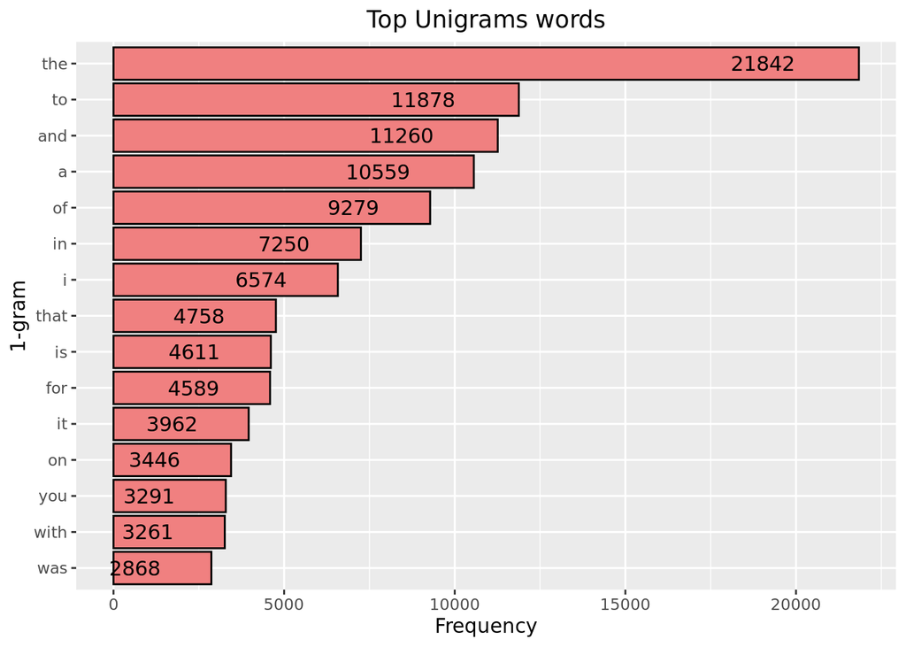

```r
all_data_unigrams <- c(twitter_file, news_file, blogs_file) %>% tokens(1)

# Plot the frequency of unigrams
unigrams_token[1:15,] %>%
  ggplot(aes(x = reorder(x, Freq), y = Freq)) +
  geom_bar(stat ='identity',
           colour = "black",
           fill = "lightcoral") +
  geom_text(label = unigrams_token$Freq[1:15],
            size = 4,
            hjust = 2) +
  xlab("1-gram") +
  ylab("Frequency") +
  ggtitle("Top Unigrams words") +
  theme(plot.title = element_text(hjust = 0.5))+
  coord_flip()
```

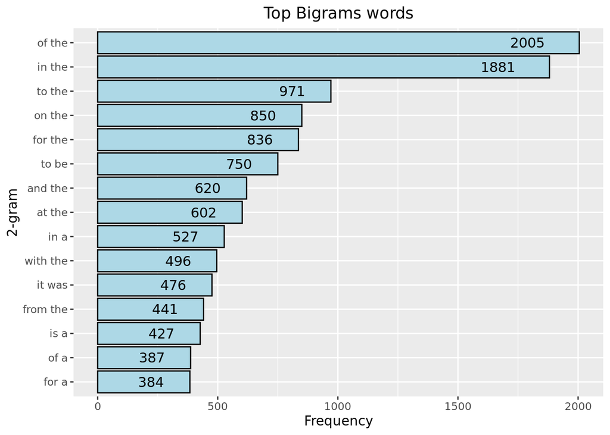

```r
# Plot the frequency of bigrams
bigrams_token[1:15,] %>%
  ggplot(aes(x = reorder(x, Freq), y = Freq)) +
  geom_bar(stat ='identity',
           colour = "black",
           fill = "lightblue") +
  geom_text(label = bigrams_token$Freq[1:15],
            size = 4,
            hjust = 2) +
  xlab("2-gram") +
  ylab("Frequency") +
  ggtitle("Top Bigrams words") +
  theme(plot.title = element_text(hjust = 0.5))+
  coord_flip()
```

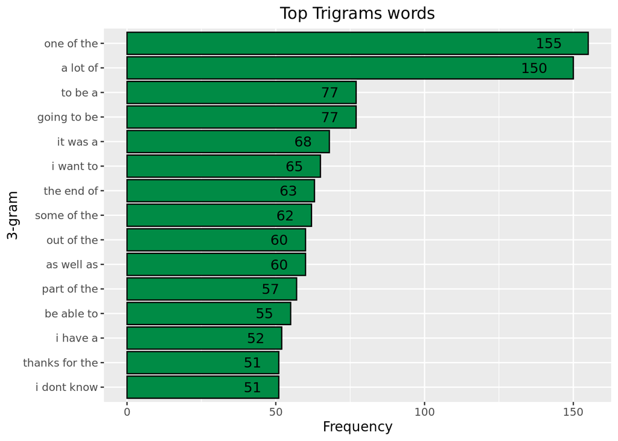

```r
# Plot the frequency of trigrams
trigrams_token[1:15,] %>%
  ggplot(aes(x = reorder(x, Freq), y = Freq)) +
  geom_bar(stat ='identity',
           colour = "black",
           fill = "springgreen4") +
  geom_text(label = trigrams_token$Freq[1:15],
            size = 4,
            hjust = 2) +
  xlab("3-gram") +
  ylab("Frequency") +
  ggtitle("Top Trigrams words") +
  theme(plot.title = element_text(hjust = 0.5))+
  coord_flip()
```

## Conclusions

After conducting a thorough examination of the dataset, we have discovered interesting insights from our exploratory analysis. With this information, we are now prepared to create and train our initial predictive model. As Machine Learning is an iterative process, we will preprocess the training data, train and evaluate the model, and then repeat these steps iteratively to achieve better performance based on our evaluation metrics.

It is important to note that each step of this process is critical, and they must be continuously re-evaluated to create an accurate and functional ML model for our predictive text application. We eagerly anticipate the upcoming report on the predictive model and the Shiny app that we will construct!